# Report 04: Detection-Floor Censoring, CRISPR Gatekeepers & Sensitivity Controls

Left-censored E2F bounds, linear molar HLA-B stoichiometry, HAP1 11-KO 2x2 Sec61 factorial, and distributed redundancy

Amir Asiaee, Nebojša Jojić, Elizabeth J. Phillips, and Simon A. Mallal

November 22, 2026

Back to Master Index | Previous: Report 03 | Next: Report 05 — Persistence & Master Verification

# 1 Detection-Floor Censoring and Linear Molar Heavy-Chain Stoichiometry Under IFN-$\gamma$

### 1.0.1 Rationale

Under intense IFN-$\gamma$ remodeling, down-regulated proliferative proteins (`Hallmark E2F Targets`) can fall below mass-spectrometry limits of detection, leaving only high-intensity survivors that reverse biological sign. Simultaneously, `ITO66T` colorectal organoids exhibit a `+0.950` $\log_2$ `HLA-B - HLA-A` protein fold-change yet negative sibling-peptide divergence (`-0.048`). I test explicit detection-floor substitutions (`L1_min`, `L1_p01`, `L1_p05`), evaluate the linear-scale molar heavy-chain gain ratio $\Delta M_B / \Delta M_A = (2^{B_1}-2^{B_0})/(2^{A_1}-2^{A_0})$, validate `HLA-B > HLA-A` sibling shifts externally in `Newey 2023` (`CRC01/04/05`, with `Pep0` ANCOVA adjustment), and track C-terminal hydrophobic vs. P4–P7 core proline shifts across 8 IFN-$\gamma$ contrasts.

```python
cens_all = pd.read_csv(res_path("exp3_inflammatory_routing", "censoring_bounds_all_programs.tsv"), sep="\t")
cens_e2f = cens_all[cens_all["program"] == "E2F_TARGETS"][["background", "n_baseline_pairs", "n_surviving_pairs", "pair_attrition_fraction", "theta_survivor", "theta_lod_min_bound", "theta_lod_p01_bound", "theta_lod_p05_bound", "sign_identified_across_lod_bounds"]]
sib_ba   = pd.read_csv(res_path("exp3_inflammatory_routing", "same_protein_hlab_vs_hlaa_siblings.tsv"), sep="\t")
mol_t    = pd.read_csv(res_path("falsification_controls", "pdo_molar_heavy_chain_stoichiometry.tsv"), sep="\t")
new_ext  = pd.read_csv(res_path("falsification_controls", "newey_external_hlab_sibling_validation.tsv"), sep="\t")
mot8     = pd.read_csv(res_path("exp3_inflammatory_routing", "proteolytic_motif_shifts_8_backgrounds.tsv"), sep="\t")[["cohort", "background", "n_surviving_peptides", "hydro_minus_nonhydro_dPep", "hydro_bh_q", "core_pro_minus_nonpro_dPep", "core_pro_bh_q"]]
```

```r
show_tbl(py$cens_e2f, digits = 3, caption = "Table 4.1: Detection-floor sensitivity bounds on source-adjusted Hallmark E2F Targets contrasts.")
```

Table 4.1: Detection-floor sensitivity bounds on source-adjusted Hallmark E2F Targets contrasts.

|  | background | n_baseline_pairs | n_surviving_pairs | pair_attrition_fraction | theta_survivor | theta_lod_min_bound | theta_lod_p01_bound | theta_lod_p05_bound | sign_identified_across_lod_bounds |
| --- | --- | --- | --- | --- | --- | --- | --- | --- | --- |
| 0 | ITO57T | 36 | 33 | 0.083 | 0.177 | 0.260 | 0.247 | 0.239 | TRUE |
| 4 | ITO58M | 25 | 24 | 0.040 | 0.060 | 0.086 | 0.086 | 0.086 | TRUE |
| 8 | ITO66T | 5 | 5 | 0.000 | 1.361 | 1.361 | 1.361 | 1.361 | TRUE |
| 11 | UWB1.289 | 78 | 42 | 0.462 | 0.478 | -0.527 | -0.022 | 0.061 | FALSE |

```r
show_tbl(py$mol_t, digits = 3, caption = "Table 4.2: Linear-scale molar heavy-chain gain ratios (dM_B / dM_A) resolving ITO66T vs. ITO58M HLA-B allocation.")
```

Table 4.2: Linear-scale molar heavy-chain gain ratios (dM_B / dM_A) resolving ITO66T vs. ITO58M HLA-B allocation.

| background | HLA_A_prot0_log2 | HLA_B_prot0_log2 | baseline_A_over_B_fold | dLog2_Prot_B_minus_A | delta_molar_B_over_A_ratio | post_IFNG_B_over_A_molar_ratio | hlab_denovo_share_ratio | same_gene_dPep_B_minus_A |
| --- | --- | --- | --- | --- | --- | --- | --- | --- |
| ITO57T | 25.743 | 23.662 | 4.230 | -0.273 | 0.138 | 0.196 | 0.575 | -0.253 |
| ITO66T | 24.049 | 20.700 | 10.187 | 0.950 | 0.241 | 0.190 | 1.109 | -0.048 |
| ITO58M | 25.319 | 24.062 | 2.389 | 0.945 | 1.167 | 0.806 | 2.971 | 0.984 |

```r
show_tbl(py$sib_ba, digits = 4, caption = "Table 4.3: Same-protein HLA-B minus HLA-A sibling divergence across Bathini PDOs and UWB1.289.")
```

Table 4.3: Same-protein HLA-B minus HLA-A sibling divergence across Bathini PDOs and UWB1.289.

| background | n_cross_locus_pairs | n_genes | mean_gene_dPep_B_minus_A | median_gene_dPep_B_minus_A | frac_genes_B_gt_A | wilcoxon_two_sided_p | measured_dProt_B_minus_A |
| --- | --- | --- | --- | --- | --- | --- | --- |
| ITO57T | 106 | 27 | -0.2526 | -0.2004 | 0.3333 | 0.1056 | -0.2727 |
| ITO58M | 206 | 61 | 0.9839 | 1.0472 | 0.8197 | 0.0000 | 0.9448 |
| ITO66T | 962 | 90 | -0.0483 | -0.1160 | 0.3778 | 0.0392 | 0.9500 |
| UWB1.289 | 207 | 87 | 1.2423 | 1.2076 | 0.8391 | 0.0000 | NaN |

```r
show_tbl(py$new_ext, digits = 4, caption = "Table 4.4: External Newey 2023 CRC PDO validation of HLA-B > HLA-A sibling shifts and Pep0 ANCOVA.")
```

Table 4.4: External Newey 2023 CRC PDO validation of HLA-B > HLA-A sibling shifts and Pep0 ANCOVA.

| cohort | background | n_genes_both_A_and_B | mean_gene_dPep_B_minus_A | pep0_controlled_ancova_B_minus_A | frac_genes_B_gt_A | wilcoxon_two_sided_p |
| --- | --- | --- | --- | --- | --- | --- |
| Newey2023 CRC PDO (external) | CRC01 | 1748 | 1.1020 | 0.9224 | 0.7551 | 0.000 |
| Newey2023 CRC PDO (external) | CRC04 | 858 | 0.1921 | 0.0825 | 0.5268 | 0.003 |
| Newey2023 CRC PDO (external) | CRC05 | 243 | 0.8400 | 0.4060 | 0.6914 | 0.000 |

```r
show_tbl(py$mot8, digits = 4, caption = "Table 4.5: C-terminal hydrophobic vs. P4-P7 core proline shifts across 8 IFN-gamma backgrounds.")
```

Table 4.5: C-terminal hydrophobic vs. P4-P7 core proline shifts across 8 IFN-gamma backgrounds.

| cohort | background | n_surviving_peptides | hydro_minus_nonhydro_dPep | hydro_bh_q | core_pro_minus_nonpro_dPep | core_pro_bh_q |
| --- | --- | --- | --- | --- | --- | --- |
| MHC1-TIP PDO | ITO57T | 1367 | 0.4294 | 0.0000 | -0.0631 | 0.1649 |
| MHC1-TIP PDO | ITO58M | 1426 | 1.0160 | 0.0000 | 0.1456 | 0.0318 |
| MHC1-TIP PDO | ITO66T | 1676 | -0.1077 | 0.0000 | 0.0837 | 0.0072 |
| Chong Ovarian | UWB1.289 | 2383 | 1.1038 | 0.0000 | 0.0743 | 0.0078 |
| Newey CRC PDO | CRC01 | 14869 | 0.4471 | 0.0000 | -0.2234 | 0.0000 |
| Newey CRC PDO | CRC04 | 7173 | 0.0210 | 0.8082 | -0.2183 | 0.0000 |
| Newey CRC PDO | CRC05 | 4505 | 0.7078 | 0.0039 | -0.3172 | 0.0000 |
| Newey CRC PDO | CRC08 | 13748 | 0.9253 | 0.0000 | -0.2848 | 0.0000 |

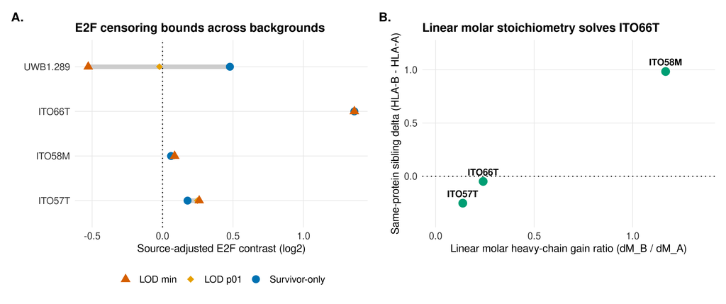

```r
p_cens <- py$cens_e2f |>
  ggplot(aes(y = background)) +
  geom_segment(aes(x = theta_lod_min_bound, xend = theta_survivor, yend = background), linewidth = 2.2, color = "grey80") +
  geom_point(aes(x = theta_survivor, color = "Survivor-only"), size = 3.2) +
  geom_point(aes(x = theta_lod_p01_bound, color = "LOD p01"), size = 3.0, shape = 18) +
  geom_point(aes(x = theta_lod_min_bound, color = "LOD min"), size = 3.2, shape = 17) +
  geom_vline(xintercept = 0, linetype = "dotted") +
  scale_color_manual(values = c("Survivor-only" = BLUE, "LOD p01" = GOLD, "LOD min" = ORANGE)) +
  labs(x = "Source-adjusted E2F contrast (log2)", y = NULL, color = NULL, title = "E2F censoring bounds across backgrounds")

p_mol <- ggplot(py$mol_t, aes(x = delta_molar_B_over_A_ratio, y = same_gene_dPep_B_minus_A, label = background)) +
  geom_hline(yintercept = 0, linetype = "dotted") +
  geom_point(size = 3.6, color = TEAL) +
  geom_text(vjust = -0.9, size = 3.4, fontface = "bold") +
  xlim(0, 1.35) + ylim(-0.4, 1.2) +
  labs(x = "Linear molar heavy-chain gain ratio (dM_B / dM_A)", y = "Same-protein sibling delta (HLA-B - HLA-A)", title = "Linear molar stoichiometry solves ITO66T")

tagged(p_cens + p_mol)
```

**What do we see?**

Tables 4.1–4.5 and Figure 4.1 resolve three quantitative anomalies under IFN-$\gamma$ inflammation:

1. **`46.2%` E2F detection-floor attrition reverses apparent sign in `UWB1.289`:** In ovarian `UWB1.289`, `36` of `78` baseline `Hallmark E2F Targets` pairs disappear below MS detection after IFN-$\gamma$ (`pair_attrition_fraction = 0.462`), leaving `42` surviving pairs with an apparent positive shift (`theta_survivor = +0.478`). Bounding lost pairs at the treated run minimum (`L1_min`) or 1st percentile (`L1_p01`) reverses sign to **`-0.527`** and `-0.022`, so E2F directionality is not sign-identified across censoring bounds (`sign_identified = FALSE`), unlike low-attrition `ITO57T` (`8.3%`), `ITO58M` (`4.0%`), and `ITO66T` (`0.0%`).
2. **Linear molar heavy-chain gain solves the `ITO66T` vs. `ITO58M` discrepancy:** Although `ITO66T` shows `+0.950` $\log_2$ `HLA-B - HLA-A` protein gain, its baseline `HLA-A` exceeds `HLA-B` by **`10.187x`** (`24.049` vs. `20.700`), yielding only `0.241` linear molar gain ratio (`dM_B / dM_A`) and keeping same-gene sibling divergence flat (`-0.0483`, Table 4.3). Conversely, `ITO58M` starts closer to parity (`2.389x` baseline ratio), achieves `dM_B / dM_A = 1.167`, and drives `82.0%` of genes (`61` genes, `206` pairs) higher on `HLA-B` (`+0.9839`, `p < 1e-4`), closely matching `UWB1.289` (`+1.2423`, `83.9%`). External `Newey 2023` CRC PDOs confirm positive `HLA-B - HLA-A` sibling divergence in `CRC01` (`+1.1020`; `+0.9224` after `Pep0` ANCOVA), `CRC04` (`+0.1921`), and `CRC05` (`+0.8400`, Table 4.4).
3. **C-terminal hydrophobic enrichment across `7 / 8` (`6 / 8` significantly positive) IFN-$\gamma$ backgrounds:** Immunoproteasome-favored C-terminal hydrophobic shifts are positive in `7 / 8` backgrounds and statistically significant (`BH q < 0.004`) in **`6 / 8`** (`+0.4294` in `ITO57T`, `+1.0160` in `ITO58M`, `+1.1038` in `UWB1.289`, and `+0.4471` to `+0.9253` in `Newey CRC01/05/08`; `CRC04` is near-neutral at `+0.0210`, `P = 0.808`, and `ITO66T` is `-0.1077`).

# 2 Isogenic `HAP1` CRISPR Gatekeepers and `2x2` `Sec61` Signal-Peptide Bypass

```python
ko11  = pd.read_csv(res_path("exp4_hap1_gatekeepers", "hap1_11ko_two_margin_summary.tsv"), sep="\t")
ldr   = pd.read_csv(res_path("exp4_hap1_gatekeepers", "hap1_leader_signal_peptide_sparing.tsv"), sep="\t")
fac_t = pd.read_csv(res_path("falsification_controls", "hap1_2x2_sec61_signal_peptide_factorial.tsv"), sep="\t")
span_t = pd.read_csv(res_path("exp8_immunity_bridge", "hap1_exact_signal_span_cleavage_audit.tsv"), sep="\t")
lor_t = pd.read_csv(res_path("falsification_controls", "hap1_batch_invariant_length_odds_ratios.tsv"), sep="\t")
top_re = pd.read_csv(res_path("exp4_hap1_gatekeepers", "tap_ko_topology_matched_reanalysis.tsv"), sep="\t")
hm2   = pd.read_csv(res_path("exp4_hap1_gatekeepers", "hallmark50_topology_in_tap2_ko.tsv"), sep="\t")
hm2_r = float(np.corrcoef(hm2["frac_signal_peptide_genes"], hm2["gene_mean_retention"])[0, 1])
```

```r
show_tbl(py$ko11[, c("knockout", "overall_retention", "ret_8mer", "ret_9mer", "ret_10mer", "ret_11mer", "denovo_frac_10_11mer")], digits = 3, caption = "Table 4.6: Retention across lengths and de novo 10-11-mer share across all 11 HAP1 APPM knockouts.")
```

Table 4.6: Retention across lengths and de novo 10-11-mer share across all 11 HAP1 APPM knockouts.

| knockout | overall_retention | ret_8mer | ret_9mer | ret_10mer | ret_11mer | denovo_frac_10_11mer |
| --- | --- | --- | --- | --- | --- | --- |
| B2M | 0.007 | 0.017 | 0.005 | 0.008 | 0.014 | 0.708 |
| CALR | 0.864 | 0.930 | 0.883 | 0.838 | 0.732 | 0.285 |
| CANX | 0.830 | 0.845 | 0.863 | 0.790 | 0.659 | 0.231 |
| ERAP1 | 0.404 | 0.291 | 0.383 | 0.487 | 0.459 | 0.781 |
| GANAB | 0.519 | 0.602 | 0.585 | 0.390 | 0.238 | 0.089 |
| IRF2 | 0.239 | 0.216 | 0.272 | 0.194 | 0.100 | 0.217 |
| PDIA3 | 0.318 | 0.389 | 0.353 | 0.251 | 0.145 | 0.110 |
| SPPL3 | 0.697 | 0.700 | 0.735 | 0.652 | 0.507 | 0.211 |
| TAP1 | 0.354 | 0.629 | 0.389 | 0.232 | 0.171 | 0.297 |
| TAP2 | 0.102 | 0.227 | 0.106 | 0.065 | 0.064 | 0.314 |
| TAPBP | 0.176 | 0.265 | 0.204 | 0.102 | 0.057 | 0.136 |

```r
show_tbl(py$fac_t, digits = 3, caption = "Table 4.7: HAP1 2x2 factorial separating N-terminal coordinate (1-35 AA) from curated UniProt signal-peptide status.")
```

Table 4.7: HAP1 2x2 factorial separating N-terminal coordinate (1-35 AA) from curated UniProt signal-peptide status.

| knockout | nterm_1_35aa | uniprot_signal_peptide | n_baseline_peptides | retention_n2_of_3 | detection_n1_of_3 | n_surviving_n2 | surv_median_dPep_log2 | surv_mean_dPep_log2 |
| --- | --- | --- | --- | --- | --- | --- | --- | --- |
| TAP1 | TRUE | TRUE | 140 | 0.871 | 0.893 | 122 | 4.461 | 4.108 |
| TAP1 | TRUE | FALSE | 894 | 0.447 | 0.569 | 400 | -0.973 | -0.451 |
| TAP1 | FALSE | TRUE | 720 | 0.396 | 0.501 | 285 | -0.099 | 0.680 |
| TAP1 | FALSE | FALSE | 13376 | 0.340 | 0.450 | 4552 | -1.318 | -1.027 |
| TAP2 | TRUE | TRUE | 140 | 0.771 | 0.800 | 108 | 6.224 | 5.646 |
| TAP2 | TRUE | FALSE | 894 | 0.158 | 0.223 | 141 | -1.741 | -0.936 |
| TAP2 | FALSE | TRUE | 720 | 0.172 | 0.211 | 124 | 2.997 | 2.367 |
| TAP2 | FALSE | FALSE | 13376 | 0.087 | 0.124 | 1165 | -2.741 | -1.998 |
| TAPBP | TRUE | TRUE | 140 | 0.500 | 0.636 | 70 | 1.664 | 1.921 |
| TAPBP | TRUE | FALSE | 894 | 0.219 | 0.302 | 196 | -0.233 | -0.427 |
| TAPBP | FALSE | TRUE | 720 | 0.156 | 0.242 | 112 | 0.622 | 0.567 |
| TAPBP | FALSE | FALSE | 13376 | 0.170 | 0.243 | 2276 | -0.280 | -0.247 |
| ERAP1 | TRUE | TRUE | 140 | 0.357 | 0.400 | 50 | -0.499 | -0.688 |
| ERAP1 | TRUE | FALSE | 894 | 0.385 | 0.471 | 344 | -0.460 | -0.458 |
| ERAP1 | FALSE | TRUE | 720 | 0.325 | 0.425 | 234 | -0.109 | -0.024 |
| ERAP1 | FALSE | FALSE | 13376 | 0.410 | 0.502 | 5482 | -0.258 | -0.169 |

```r
show_tbl(py$span_t, digits = 3, caption = "Table 4.7b: Exact UniProt FT_SIGNAL cleavage-interval audit comparing peptides strictly inside cleaved signal spans vs. mature-chain downstream peptides.")
```

Table 4.7b: Exact UniProt FT_SIGNAL cleavage-interval audit comparing peptides strictly inside cleaved signal spans vs. mature-chain downstream peptides.

| knockout | span_category | n_baseline_peptides | retention_n2_of_3 | n_surviving_n2 | surv_median_dPep_log2 |
| --- | --- | --- | --- | --- | --- |
| TAP1 | 1_Strictly_Inside_Cleaved_FT_SIGNAL | 102 | 0.892 | 91 | 4.866 |
| TAP1 | 2_Spans_FT_SIGNAL_Cleavage_Junction | 8 | 0.875 | 7 | 3.953 |
| TAP1 | 3_Mature_Chain_Downstream_of_FT_SIGNAL | 747 | 0.412 | 308 | 0.197 |
| TAP1 | 4_Unannotated_Gene_Nterm_le35 | 894 | 0.447 | 400 | -0.973 |
| TAP1 | 5_Unannotated_Gene_Internal_gt35 | 13379 | 0.340 | 4553 | -1.317 |
| TAP2 | 1_Strictly_Inside_Cleaved_FT_SIGNAL | 102 | 0.833 | 85 | 6.563 |
| TAP2 | 2_Spans_FT_SIGNAL_Cleavage_Junction | 8 | 0.625 | 5 | 6.309 |
| TAP2 | 3_Mature_Chain_Downstream_of_FT_SIGNAL | 747 | 0.189 | 141 | 2.984 |
| TAP2 | 4_Unannotated_Gene_Nterm_le35 | 894 | 0.158 | 141 | -1.741 |
| TAP2 | 5_Unannotated_Gene_Internal_gt35 | 13379 | 0.087 | 1166 | -2.741 |
| TAPBP | 1_Strictly_Inside_Cleaved_FT_SIGNAL | 102 | 0.529 | 54 | 1.685 |
| TAPBP | 2_Spans_FT_SIGNAL_Cleavage_Junction | 8 | 0.125 | 1 | 0.544 |
| TAPBP | 3_Mature_Chain_Downstream_of_FT_SIGNAL | 747 | 0.170 | 127 | 0.668 |
| TAPBP | 4_Unannotated_Gene_Nterm_le35 | 894 | 0.219 | 196 | -0.233 |
| TAPBP | 5_Unannotated_Gene_Internal_gt35 | 13379 | 0.170 | 2276 | -0.280 |
| ERAP1 | 1_Strictly_Inside_Cleaved_FT_SIGNAL | 102 | 0.363 | 37 | -0.096 |
| ERAP1 | 2_Spans_FT_SIGNAL_Cleavage_Junction | 8 | 0.375 | 3 | -1.806 |
| ERAP1 | 3_Mature_Chain_Downstream_of_FT_SIGNAL | 747 | 0.325 | 243 | -0.125 |
| ERAP1 | 4_Unannotated_Gene_Nterm_le35 | 894 | 0.385 | 344 | -0.460 |
| ERAP1 | 5_Unannotated_Gene_Internal_gt35 | 13379 | 0.410 | 5483 | -0.258 |

```r
show_tbl(py$lor_t[, c("knockout", "run_date", "ko_10_11mer_share", "within_repertoire_10_11mer_odds_ratio_vs_wt")], digits = 3, caption = "Table 4.8: Batch-invariant within-sample (10-11mer / 8-9mer) length odds ratios vs. WT.")
```

Table 4.8: Batch-invariant within-sample (10-11mer / 8-9mer) length odds ratios vs. WT.

| knockout | run_date | ko_10_11mer_share | within_repertoire_10_11mer_odds_ratio_vs_wt |
| --- | --- | --- | --- |
| B2M | 20201218 | 0.450 | 2.166 |
| ERAP1 | 20201211 | 0.347 | 1.405 |
| CALR | 20201202 | 0.257 | 0.915 |
| CANX | 20201204 | 0.248 | 0.872 |
| SPPL3 | 20201211 | 0.240 | 0.836 |
| TAP2 | 20201127 | 0.206 | 0.686 |
| IRF2 | 20201214 | 0.188 | 0.614 |
| PDIA3 | 20201207 | 0.187 | 0.610 |
| GANAB | 20201204 | 0.180 | 0.581 |
| TAP1 | 20201127 | 0.179 | 0.579 |
| TAPBP | 20201209 | 0.144 | 0.447 |

```r
show_tbl(py$top_re, digits = 3, caption = "Table 4.9: Topology-mismatched vs. topology-matched EMT and Inflammatory contrasts in TAP1/TAP2 KOs.")
```

Table 4.9: Topology-mismatched vs. topology-matched EMT and Inflammatory contrasts in TAP1/TAP2 KOs.

| knockout | program | n_baseline_pairs | target_sec_frac | control_sec_frac | target_sigpep_frac | control_sigpep_frac | n_surviving_pairs | all_survivors_mean_pair_u | topology_mismatched_n | topology_mismatched_mean_pair_u | topology_matched_n | topology_matched_mean_pair_u |
| --- | --- | --- | --- | --- | --- | --- | --- | --- | --- | --- | --- | --- |
| TAP1 | EPITHELIAL_MESENCHYMAL_TRANSITION | 76 | 0.566 | 0.211 | 0.224 | 0.026 | 34 | 0.788 | 19 | 1.303 | 13 | 0.341 |
| TAP1 | E2F_TARGETS | 597 | 0.047 | 0.211 | 0.003 | 0.018 | 159 | 0.072 | 6 | -0.032 | 127 | -0.029 |
| TAP1 | INTERFERON_GAMMA_RESPONSE | 98 | 0.204 | 0.245 | 0.071 | 0.031 | 19 | 1.119 | 3 | 3.038 | 11 | 0.849 |
| TAP2 | EPITHELIAL_MESENCHYMAL_TRANSITION | 76 | 0.566 | 0.211 | 0.224 | 0.026 | 7 | 1.949 | 3 | 4.241 | 4 | 0.230 |
| TAP2 | E2F_TARGETS | 597 | 0.047 | 0.211 | 0.003 | 0.018 | 36 | -0.014 | 1 | 1.150 | 28 | 0.071 |
| TAP2 | INTERFERON_GAMMA_RESPONSE | 98 | 0.204 | 0.245 | 0.071 | 0.031 | 2 | 4.985 | 1 | 10.600 | 0 | NaN |

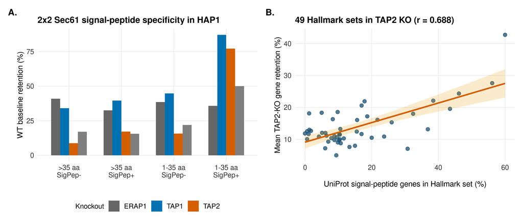

```r
p_fac <- py$fac_t |>
  mutate(Quad = paste0(ifelse(nterm_1_35aa, "1-35 aa", ">35 aa"), "\n", ifelse(uniprot_signal_peptide, "SigPep+", "SigPep-"))) |>
  ggplot(aes(x = Quad, y = 100 * retention_n2_of_3, fill = knockout)) +
  geom_col(position = "dodge", width = 0.68) +
  scale_fill_manual(values = c(TAP1 = BLUE, TAP2 = ORANGE, ERAP1 = GRAY)) +
  labs(x = NULL, y = "WT baseline retention (%)", fill = "Knockout", title = "2x2 Sec61 signal-peptide specificity in HAP1")

p_hm <- ggplot(py$hm2, aes(x = 100 * frac_signal_peptide_genes, y = 100 * gene_mean_retention)) +
  geom_point(size = 2.2, color = NAVY, alpha = 0.75) +
  geom_smooth(method = "lm", se = TRUE, color = ORANGE, fill = GOLD, alpha = 0.2) +
  labs(x = "UniProt signal-peptide genes in Hallmark set (%)", y = "Mean TAP2-KO gene retention (%)", title = sprintf("49 Hallmark sets in TAP2 KO (r = %.3f)", py$hm2_r))

tagged(p_fac + p_hm)
```

**What do we see?**

Tables 4.6–4.9 and Figure 4.2 dissect intracellular processing checkpoints across all 11 isogenic `HAP1` knockouts:

- **Opposing ER trimming vs. PLC length rules (Tables 4.6 & 4.8):** Deleting *ERAP1* halves overall retention (`0.404`), produces **`78.1%`** `de novo` `10–11`-mers (`0.291` 8-mer retention vs. `0.487` 10-mer), and raises the batch-invariant within-sample `(10-11mer / 8-9mer)` odds ratio vs. WT to **`1.405`** (`B2M` KO `2.166`, though near zero absolute yield at `0.7%` retention). Conversely, peptide-loading-complex chaperone deletions disproportionately prune longer ligands (`TAPBP` overall `0.176`, `8`-mer `0.265` -> `11`-mer `0.057`, length OR `0.447`; `PDIA3` OR `0.610`; `GANAB` OR `0.581`; `TAP1` OR `0.579`).
- **2x2 factorial `Sec61` signal-peptide bypass (`250x` median shift gap, Table 4.7):** Crossing N-terminal coordinate (`1–35 AA` vs. `>35 AA`) against curated `UniProt` signal-peptide annotation isolates co-translational ER translocation exclusively to `1–35 AA` `SigPep+` peptides (`n = 140`): in `TAP2` KO they survive at **`77.1%`** (`n >= 2/3`) with median $\Delta\log_2 = +6.224$ (`TAP1` KO `87.1%`, `+4.461`), whereas `1–35 AA` `SigPep-` cytosolic N-terminal peptides collapse to **`15.8%`** (`-1.741`; a **`250x`** median fold-change ratio of $2^{6.224 - (-1.741)} = 2^{7.965}$). Negative-control `ERAP1` KO shows flat retention (`32.5%–41.0%`) across all four quadrants.
- **Pathway-topology bias ($r = 0.688$, Table 4.9):** Across `49` `Hallmark` gene sets in `TAP2` KO, mean gene retention correlates directly with `UniProt` signal-peptide share ($r = 0.688$), so extracellular-enriched `EMT` pairs appear spared (`+4.241` in `TAP2` KO, `n = 3`) only when topology-mismatched; matching target vs. background topology collapses the apparent `EMT` gap from `+4.241` to `+0.230` (`+1.303 -> +0.341` in `TAP1` KO).

# 3 Distributed-Mixture Redundancy, Subsampled Depth Curves, and Temporal Trajectories

### 3.0.1 Rationale

Finally, I stress-test three properties of the cross-lineage `PosAA180` decoder: (1) removing up to `50%` of the most discriminating source genes before renormalizing versus sparse `Top-1`, `Top-5`, and `Top-10` peptide panels, plus 5-fold strictly gene-disjoint `20%` splits; (2) downsampling random 9-mer budgets from `M = 25` to `2,000` peptides per condition; and (3) temporal trajectory buildup (`24 h -> 48–72 h`) in `Bernhardt pSILAC` and `Stopfer 2022` xenografts alongside the negative limit on continuous mixed RNA/proteome `Hallmark` magnitudes (`13` contrasts, `11` lineages).

```python
abl_t  = pd.read_csv(res_path("exp7_distributional_sensing", "exp7d_marker_ablation_vs_panels.tsv"), sep="\t")
bud_t  = pd.read_csv(res_path("exp7_distributional_sensing", "exp7d_peptide_budget_curve.tsv"), sep="\t")
cont_t = pd.read_csv(res_path("exp7_distributional_sensing", "exp7c_continuous_program_shift_recovery.tsv"), sep="\t")
traj_t = pd.read_csv(res_path("exp7_distributional_sensing", "exp7e_temporal_trajectories.tsv"), sep="\t")
traj_sum = traj_t.groupby(["cohort", "bio_state", "time_h"], as_index=False)[["l2_shift_pos180", "l2_shift_coarse96", "d_mda_share_pct"]].mean()
```

```r
show_tbl(py$abl_t, digits = 3, caption = "Table 4.10: Top-gene ablation curve (0-50%) vs. sparse Top-1..Top-25 peptide panels across 35 contrasts.")
```

Table 4.10: Top-gene ablation curve (0-50%) vs. sparse Top-1..Top-25 peptide panels across 35 contrasts.

| mode | frac_genes_removed | lolo_auroc_pos180 | lolo_auroc_anchor40 | zero_feature_test_contrasts |
| --- | --- | --- | --- | --- |
| Top_1_Peptide_Markers_Only | 0.00 | 0.252 | 0.252 | 34 |
| Top_3_Peptide_Markers_Only | 0.00 | 0.810 | 0.810 | 16 |
| Top_5_Peptide_Markers_Only | 0.00 | 0.846 | 0.846 | 5 |
| Top_10_Peptide_Markers_Only | 0.00 | 0.602 | 0.602 | 4 |
| Top_25_Peptide_Markers_Only | 0.00 | 0.698 | 0.698 | 2 |
| Collective_Distribution_After_TopGene_Ablation | 0.00 | 0.948 | 0.936 | 0 |
| Collective_Distribution_After_TopGene_Ablation | 0.01 | 0.936 | 0.972 | 0 |
| Collective_Distribution_After_TopGene_Ablation | 0.05 | 0.816 | 0.760 | 0 |
| Collective_Distribution_After_TopGene_Ablation | 0.10 | 0.860 | 0.776 | 0 |
| Collective_Distribution_After_TopGene_Ablation | 0.25 | 0.728 | 0.612 | 0 |
| Collective_Distribution_After_TopGene_Ablation | 0.50 | 0.620 | 0.712 | 0 |

```r
show_tbl(py$bud_t, digits = 3, caption = "Table 4.11: Subsampled 9-mer repertoire budget scaling curve (M = 25 to 2,000).")
```

Table 4.11: Subsampled 9-mer repertoire budget scaling curve (M = 25 to 2,000).

| peptide_budget_M | mean_auroc_anchor40 | sd_auroc_anchor40 | mean_auroc_pos180 | sd_auroc_pos180 |
| --- | --- | --- | --- | --- |
| 25 | 0.480 | 0.148 | 0.498 | 0.145 |
| 50 | 0.546 | 0.123 | 0.511 | 0.148 |
| 100 | 0.512 | 0.173 | 0.514 | 0.167 |
| 250 | 0.554 | 0.137 | 0.513 | 0.189 |
| 500 | 0.675 | 0.145 | 0.603 | 0.110 |
| 1000 | 0.710 | 0.168 | 0.722 | 0.117 |
| 2000 | 0.721 | 0.117 | 0.775 | 0.110 |

```r
show_tbl(py$cont_t, digits = 3, caption = "Table 4.12: Continuous Hallmark IFN-gamma and E2F magnitude recovery across 13 multi-omic contrasts (11 lineages).")
```

Table 4.12: Continuous Hallmark IFN-gamma and E2F magnitude recovery across 13 multi-omic contrasts (11 lineages).

| program_axis | representation | n_contrasts | n_unique_lineages | lolo_pearson_r | lolo_pearson_p | lolo_relative_mse_vs_mean |
| --- | --- | --- | --- | --- | --- | --- |
| Hallmark_IFNg_Response | R0_Quantity_Depth | 13 | 11 | -0.792 | 0.001 | 1.242 |
| Hallmark_IFNg_Response | R1_Coarse96 | 13 | 11 | -0.160 | 0.603 | 1.122 |
| Hallmark_IFNg_Response | R2c_Anchor40 | 13 | 11 | -0.566 | 0.044 | 1.516 |
| Hallmark_IFNg_Response | R2_PosAA180 | 13 | 11 | -0.349 | 0.243 | 1.986 |
| Hallmark_E2F_Targets | R0_Quantity_Depth | 13 | 11 | -0.352 | 0.238 | 1.342 |
| Hallmark_E2F_Targets | R1_Coarse96 | 13 | 11 | -0.168 | 0.583 | 2.582 |
| Hallmark_E2F_Targets | R2c_Anchor40 | 13 | 11 | -0.608 | 0.028 | 1.563 |
| Hallmark_E2F_Targets | R2_PosAA180 | 13 | 11 | -0.296 | 0.325 | 1.136 |

```r
show_tbl(py$traj_sum, digits = 3, caption = "Table 4.13: Mean temporal L2 shifts and MDA shares across Bernhardt 2025 pSILAC and Stopfer 2022 xenografts.")
```

Table 4.13: Mean temporal L2 shifts and MDA shares across Bernhardt 2025 pSILAC and Stopfer 2022 xenografts.

| cohort | bio_state | time_h | l2_shift_pos180 | l2_shift_coarse96 | d_mda_share_pct |
| --- | --- | --- | --- | --- | --- |
| Bernhardt2025_pSILAC | IFNg_Inflammatory | 24 | 0.119 | 0.096 | 0.914 |
| Bernhardt2025_pSILAC | IFNg_Inflammatory | 72 | 0.159 | 0.094 | 1.517 |
| Bernhardt2025_pSILAC | MAPKi_Resistant_NoResponse | 24 | 0.268 | 0.168 | 0.318 |
| Bernhardt2025_pSILAC | MAPKi_Resistant_NoResponse | 72 | 0.208 | 0.148 | 0.860 |
| Bernhardt2025_pSILAC | MAPKi_Sensitive_Response | 24 | 0.156 | 0.140 | 1.811 |
| Bernhardt2025_pSILAC | MAPKi_Sensitive_Response | 48 | 0.163 | 0.129 | 0.182 |
| Bernhardt2025_pSILAC | MAPKi_Sensitive_Response | 72 | 0.243 | 0.210 | 3.921 |
| Bernhardt2025_pSILAC | Mock_Control | 24 | 0.085 | 0.072 | -0.006 |
| Bernhardt2025_pSILAC | Mock_Control | 48 | 0.084 | 0.066 | -0.265 |
| Bernhardt2025_pSILAC | Mock_Control | 72 | 0.093 | 0.071 | -0.212 |
| Stopfer2022_Xenograft_TimeCourse | Xenograft_BiniEncor | 72 | 0.081 | 0.059 | 1.715 |
| Stopfer2022_Xenograft_TimeCourse | Xenograft_Binimetinib | 24 | 0.068 | 0.049 | 0.077 |
| Stopfer2022_Xenograft_TimeCourse | Xenograft_Binimetinib | 48 | 0.058 | 0.041 | 0.206 |
| Stopfer2022_Xenograft_TimeCourse | Xenograft_Binimetinib | 72 | 0.063 | 0.040 | 0.636 |
| Stopfer2022_Xenograft_TimeCourse | Xenograft_Binimetinib | 120 | 0.086 | 0.063 | 1.163 |
| Stopfer2022_Xenograft_TimeCourse | Xenograft_Encorafenib | 72 | 0.074 | 0.059 | 1.656 |

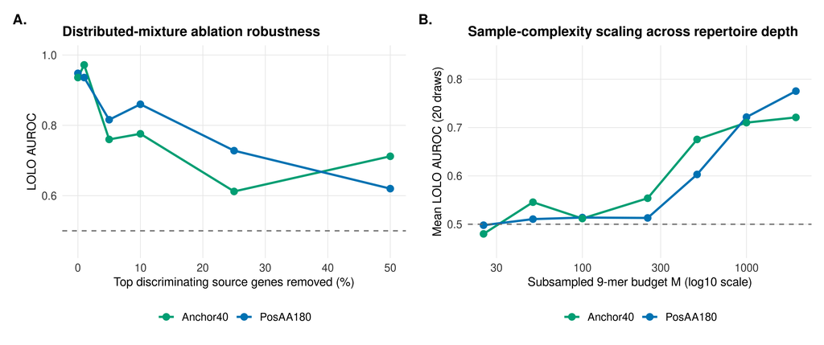

```r
abl_coll <- py$abl_t |>
  filter(mode == "Collective_Distribution_After_TopGene_Ablation") |>
  pivot_longer(c(lolo_auroc_pos180, lolo_auroc_anchor40), names_to = "Rep", values_to = "AUROC") |>
  mutate(Rep = recode(Rep, lolo_auroc_pos180 = "PosAA180", lolo_auroc_anchor40 = "Anchor40"))

p_ab <- ggplot(abl_coll, aes(x = 100 * frac_genes_removed, y = AUROC, color = Rep)) +
  geom_line(linewidth = 0.95) +
  geom_point(size = 2.6) +
  geom_hline(yintercept = 0.5, linetype = "dashed", color = GRAY) +
  scale_color_manual(values = c(PosAA180 = BLUE, Anchor40 = TEAL)) +
  ylim(0.45, 1.0) +
  labs(x = "Top discriminating source genes removed (%)", y = "LOLO AUROC", color = NULL, title = "Distributed-mixture ablation robustness")

bud_long <- py$bud_t |>
  pivot_longer(c(mean_auroc_pos180, mean_auroc_anchor40), names_to = "Rep", values_to = "AUROC") |>
  mutate(Rep = recode(Rep, mean_auroc_pos180 = "PosAA180", mean_auroc_anchor40 = "Anchor40"))

p_bd <- ggplot(bud_long, aes(x = peptide_budget_M, y = AUROC, color = Rep)) +
  geom_line(linewidth = 0.95) +
  geom_point(size = 2.6) +
  scale_x_log10() +
  geom_hline(yintercept = 0.5, linetype = "dashed", color = GRAY) +
  scale_color_manual(values = c(PosAA180 = BLUE, Anchor40 = TEAL)) +
  ylim(0.45, 0.85) +
  labs(x = "Subsampled 9-mer budget M (log10 scale)", y = "Mean LOLO AUROC (20 draws)", color = NULL, title = "Sample-complexity scaling across repertoire depth")

tagged(p_ab + p_bd)
```

**What do we see?**

**Decision point:**

I now proceed to the final report, Report 05, to predict post-IFN-$\gamma$ peptide persistence across `N = 6,998` baseline ligands, resolve Simpson’s paradox in pooled regression, verify all `12` manuscript PDFs and `5` deposited summary CSV tables, and audit all `45 / 45` deterministic invariants.